# Methods

**In overall, in order to measure the similarity in the distribution of baby names among states, we first use cross-correlation matrix to quantify the similiarity. Then use principal component analysis (PCA) of the matrices of states correlation to separate the true systematic similarity from random noise. Besides PCA, we also use hierarchical clustering and K-means clustering on the cross-correlation matrix among states to group similar states into the same groups.**

In this section, it covers the methods are used to compute:

(1) The frequency of each name in the state, respectively

(2) The average frequency of the each name over the 51 states

(3) The fluctuations of the frequencies of the names over the states

(4) The corelations between the fluctuations of names in any pair of the states

(5) PCA: separate the underlaying noise from true similarity pattern

(6) Coverted positive definite correlation matrix (for Hierarchael Clustering & K-means Clustering)

(7) Plot PC 1 and PC 2 in order to decide the clustering number

(8) Hierarchael Clustering

(9) K-means Clustering

### Data From Pre-processing step

```python
# -*- coding: utf-8 -*-
from __future__ import division
import numpy as np
import pandas as pd
from sklearn import linear_model
import matplotlib
import matplotlib.pyplot as plt
from sklearn.metrics import r2_score
import matplotlib.cm as cmx
import matplotlib.colors as colors
from sklearn.decomposition import PCA
import pickle
from sklearn import preprocessing
from sklearn.cluster import AgglomerativeClustering
from sklearn.cluster import KMeans
%matplotlib inline
```

```python
## Import Data (Biblical Names Only)
f = open('data.pkl', 'rb')
dfList = pickle.load(f)
f.close()

## Whole baby names
with open('data_matrix_event.pkl', 'rb') as f1:
    [df_WWII_before, df_WWII_after, df_depression_before, df_depression_after, df_fe_before, df_fe_after, df_ma_before, df_ma_after, df_alaska_before, df_alaska_after] = pickle.load(f1)
f1.close()
```

## Processing Data Before Using Functions From Methods:

In the previous data processing step, we have organze the data into a matrix format, where each column is a state, each row is a baby name, and each cell in the matrix is the count of that baby name in that state. In the following steps, we will first choose some data for the later analysis part, and then introduce how to use several functions to convert them to a desired format.

### Select years to explore whether there is a changing pattern for state-state relationship over time

```python
#some selected years to see whether the state & state relationship changes over time
years = np.arange(1910, 2002, 4)
years
```

```
array([1910, 1914, 1918, 1922, 1926, 1930, 1934, 1938, 1942, 1946, 1950,
       1954, 1958, 1962, 1966, 1970, 1974, 1978, 1982, 1986, 1990, 1994,
       1998])
```

```python
#change Nan values to 0
for i in years:
    dfList[i] = dfList[i].fillna(0)
```

```python
dfList[1910].head(5)
```

|  | Aaron | Abba | Abdi | Abdiel | Abdon | Abel | Abiel | Abigail | Abilene | Abner | ... | Zedekiah | Zemira | Zenas | Zephaniah | Zia | Zina | Zion | Zipporah | Zohar | Zorah |
| --- | --- | --- | --- | --- | --- | --- | --- | --- | --- | --- | --- | --- | --- | --- | --- | --- | --- | --- | --- | --- | --- |
| AK | 0 | 0 | 0 | 0 | 0 | 0 | 0 | 0 | 0 | 0 | ... | 0 | 0 | 0 | 0 | 0 | 0 | 0 | 0 | 0 | 0 |
| AL | 7 | 0 | 0 | 0 | 0 | 0 | 0 | 0 | 0 | 0 | ... | 0 | 0 | 0 | 0 | 0 | 0 | 0 | 0 | 0 | 0 |
| AR | 6 | 0 | 0 | 0 | 0 | 0 | 0 | 0 | 0 | 0 | ... | 0 | 0 | 0 | 0 | 0 | 0 | 0 | 0 | 0 | 0 |
| AZ | 0 | 0 | 0 | 0 | 0 | 0 | 0 | 0 | 0 | 0 | ... | 0 | 0 | 0 | 0 | 0 | 0 | 0 | 0 | 0 | 0 |
| CA | 0 | 0 | 0 | 0 | 0 | 0 | 0 | 0 | 0 | 0 | ... | 0 | 0 | 0 | 0 | 0 | 0 | 0 | 0 | 0 | 0 |

5 rows × 522 columns

### Using selected biblical names: To explore how Christianity related social events influence the migration in the U.S.

#### Civil Rights Movement

As the center of community life, Black churches held a leadership role in the Civil Rights Movement. Their history as a focal point for the Black community and as a link between the Black and White worlds made them natural for this purpose.

Rev. Martin Luther King, Jr. was but one of many notable Black ministers involved in the movement. He helped found the Southern Christian Leadership Conference (1957), serving as its first president. King received the Nobel Peace Prize for his efforts to end segregation and racial discrimination through non-violent civil disobedience. He was assassinated in 1968.

Civil Rights movement was widely considered as between 1954-1968. Therefore we decided to compare the data 10 years before and after the movement.

```python
df_tmp = pd.DataFrame(index=dfList[1990].index, columns = dfList[1990].columns).fillna(0)
for year in range(1944,1954):
    df_tmp = df_tmp.add(dfList[year].fillna(0))
df_civil_before = df_tmp.copy(deep=True)

df_tmp = pd.DataFrame(index=dfList[1990].index, columns = dfList[1990].columns).fillna(0)
for year in range(1969,1979):
    df_tmp = df_tmp.add(dfList[year].fillna(0))
df_civil_after = df_tmp.copy(deep=True)
```

```python
df_civil_before.head(5)
# print df_civil_after.head(5)
```

|  | Aaron | Abba | Abdi | Abdiel | Abdon | Abel | Abiel | Abigail | Abilene | Abner | ... | Zedekiah | Zemira | Zenas | Zephaniah | Zia | Zina | Zion | Zipporah | Zohar | Zorah |
| --- | --- | --- | --- | --- | --- | --- | --- | --- | --- | --- | --- | --- | --- | --- | --- | --- | --- | --- | --- | --- | --- |
| AK | 0 | 0 | 0 | 0 | 0 | 0 | 0 | 0 | 0 | 0 | ... | 0 | 0 | 0 | 0 | 0 | 0 | 0 | 0 | 0 | 0 |
| AL | 351 | 0 | 0 | 0 | 0 | 0 | 0 | 0 | 0 | 0 | ... | 0 | 0 | 0 | 0 | 0 | 0 | 0 | 0 | 0 | 0 |
| AR | 160 | 0 | 0 | 0 | 0 | 0 | 0 | 0 | 0 | 0 | ... | 0 | 0 | 0 | 0 | 0 | 0 | 0 | 0 | 0 | 0 |
| AZ | 16 | 0 | 0 | 0 | 0 | 25 | 0 | 0 | 0 | 0 | ... | 0 | 0 | 0 | 0 | 0 | 0 | 0 | 0 | 0 | 0 |
| CA | 312 | 0 | 0 | 0 | 0 | 221 | 0 | 79 | 0 | 0 | ... | 0 | 0 | 0 | 0 | 0 | 6 | 0 | 0 | 0 | 0 |

5 rows × 522 columns

#### Separation of Church and State

Another noticable event in religious history is the "separation of church and state" movement, which became a definitive part of Establishment Clause jurisprudence in Everson v. Board of Education, 330 U.S. 1 (1947), a case that dealt with a state law that allowed government funds for transportation to religious schools. While the ruling upheld the state law allowing taxpayer funding of transportation to religious schools as constitutional, Everson was also the first case to hold the Establishment Clause applicable to the state legislatures as well as Congress, based upon the due process clause of the Fourteenth Amendment.

We also compare the data 10 years before and after the movement.

```python
df_tmp = pd.DataFrame(index=dfList[1990].index, columns = dfList[1990].columns).fillna(0)
for year in range(1937,1947):
    df_tmp = df_tmp.add(dfList[year].fillna(0))
df_seperation_before = df_tmp.copy(deep=True)

df_tmp = pd.DataFrame(index=dfList[1990].index, columns = dfList[1990].columns).fillna(0)
for year in range(1948,1958):
    df_tmp = df_tmp.add(dfList[year].fillna(0))
df_seperation_after = df_tmp.copy(deep=True)
```

```python
df_seperation_before.head(5)
# print df_seperation_after.head(5)
```

|  | Aaron | Abba | Abdi | Abdiel | Abdon | Abel | Abiel | Abigail | Abilene | Abner | ... | Zedekiah | Zemira | Zenas | Zephaniah | Zia | Zina | Zion | Zipporah | Zohar | Zorah |
| --- | --- | --- | --- | --- | --- | --- | --- | --- | --- | --- | --- | --- | --- | --- | --- | --- | --- | --- | --- | --- | --- |
| AK | 0 | 0 | 0 | 0 | 0 | 0 | 0 | 0 | 0 | 0 | ... | 0 | 0 | 0 | 0 | 0 | 0 | 0 | 0 | 0 | 0 |
| AL | 349 | 0 | 0 | 0 | 0 | 0 | 0 | 0 | 0 | 5 | ... | 0 | 0 | 0 | 0 | 0 | 0 | 0 | 0 | 0 | 0 |
| AR | 127 | 0 | 0 | 0 | 0 | 0 | 0 | 0 | 0 | 0 | ... | 0 | 0 | 0 | 0 | 0 | 0 | 0 | 0 | 0 | 0 |
| AZ | 6 | 0 | 0 | 0 | 0 | 11 | 0 | 0 | 0 | 0 | ... | 0 | 0 | 0 | 0 | 0 | 0 | 0 | 0 | 0 | 0 |
| CA | 135 | 0 | 0 | 0 | 0 | 114 | 0 | 13 | 0 | 0 | ... | 0 | 0 | 0 | 0 | 0 | 0 | 0 | 0 | 0 | 0 |

5 rows × 522 columns

## Using all baby names: To explore how social events influence the migration in the U.S.

Concerning the following major social events: WWII, Great Depression, Second wave feminism, Hawaii and Alaski admitted as states

```python
#Example1: WWII
df_WWII_before.head()
```

|  | Mary | Annie | Anna | Margaret | Helen | Elsie | Lucy | Dorothy | Ruth | Elizabeth | ... | Cebert | Erman | Herold | Donley | Donzel | Edgel | Delmos | Delmus | Coalton | Wyoma |
| --- | --- | --- | --- | --- | --- | --- | --- | --- | --- | --- | --- | --- | --- | --- | --- | --- | --- | --- | --- | --- | --- |
| AK | 323 | 34 | 57 | 105 | 79 | 5 | 28 | 62 | 54 | 96 | ... | 0 | 0 | 0 | 0 | 0 | 0 | 0 | 0 | 0 | 0 |
| AL | 177 | 2279 | 910 | 3729 | 3271 | 610 | 768 | 3068 | 2163 | 2840 | ... | 0 | 0 | 0 | 0 | 0 | 0 | 0 | 0 | 0 | 0 |
| AR | 2634 | 1288 | 1423 | 1974 | 2566 | 461 | 326 | 3572 | 1617 | 1079 | ... | 0 | 0 | 0 | 0 | 0 | 0 | 0 | 0 | 0 | 0 |
| AZ | 2718 | 206 | 218 | 687 | 822 | 132 | 254 | 581 | 386 | 257 | ... | 0 | 0 | 0 | 0 | 0 | 0 | 0 | 0 | 0 | 0 |
| CA | 108 | 512 | 1270 | 3625 | 4201 | 693 | 713 | 5710 | 3144 | 2319 | ... | 0 | 0 | 0 | 0 | 0 | 0 | 0 | 0 | 0 | 0 |

5 rows × 30274 columns

```python
#consist number of baby names as features
print df_WWII_before.shape
print df_WWII_after.shape
```

```
(51, 30274)
(51, 30274)
```

## Methods:

### Method section part 1 : compute the frequency of each name in the state

The first step to evluate the how baby names in a state are correlated to names in another state is to compute the frequency of each name. Assume we have total N names in the data set, we will assign q = 1 for the first name, and q = N is the last name, q will range from 1 to N. Similarly, for total 51 states, we use S to denote the state, then $f_s(q)$ represents the frequency of name $q$ in the state $s, q = 1,...,N, s = 1,..., 51.$

The the frequency of each name q in the state S is: $f_s(q) = \frac{n_s(q)}{\sum\limits_{q=1}^N n_s(q)}$, where $n_s(q)$ is the total count of name q in state s.

### Method section part 2: The average frequency of the each name over the 51 states

The second step is to compute the average frequency of the each name over the 51 states. The average frequency of name q over the 51 states is defined as:

$\overline{f(q)} = \frac{1}{51}\sum\limits_{s=1}^{51} f_s(q)$, where $f_s(q)$ is computed in step 1.

### Method section part 3: The fluctuations of the frequencies of the names over the states

We want to aggregate the names information for each state, so that we can compute the correlation among states in terms of these names together. Before doing that, we need to compute the fluctuations of the frequencies of names over the states. The frequency of name q in state s is compute by: $\overline{f_s(q)} = f_s(q) - \overline{f(q)}$.

### Method section part 4: The corelations between the fluctuations of names in any pair of the states

After quantify the each name in each states as a fluctuation, we use the Pearson correlation between the fluctuation of all names in state $i$ and the fluctuation of all names in state $j$ for each year by following formula (basically, it is Pearson correlation formula):

$C_{ij} = \frac{\sum\limits_{q=1}^{N}\overline{f_i(q)}\overline{f_j(q)}}{\sqrt{\sum\limits_{q=1}^{N}{\overline{f_i(q)}}^2}\sqrt{\sum\limits_{q=1}^{N}{\overline{f_j(q)}}^2}}$.

The correlation matrix is a 51 by 51 matrix, which compute the how the names in the state $i$ are correlated with the names in the state $j$ for all pair of state $(i, j)$ in the 51 states. For each year, we can generate a correlation matrix among states. It can be used capture the emergence of complex correlations between clusters of states.

```python
#Function: corrstate: compute state by state corrleation between the fluctuations of the frequencies of the names over the states
#Input: df: dataframe has states as rows and names as columns for each year
#Return: corr_matrix: matrix contains the Pearson correlation between the flucuations of name in state i and state j
#        for all states in the fluctuation;
def corrstate(df):
    #sum the count of name by states
    total_sum = df.sum(axis = 1)
    #divide the count of name in each state by the previous sum
    df1 = df.div(total_sum.ix[0],axis='columns')
    statenum = df1.shape[0]
    name_sum = df1.sum(axis = 0)
    #count the average frequency of name over the states
    averfreq = name_sum/float(statenum)
    #use the frequency of name in the state - average frequency of the name over states (he flucuations of name)
    fluctuation = df1.subtract(averfreq, axis ='columns')
    #compute the Pearson correlation among 51 states * 51 states
    return np.corrcoef(fluctuation)
```

### Method section 5: use PCA separate the underlaying noise from true similarity pattern

One concern for the above correlation matrix is that the correlation among states may due to the random noise instead of the true similarity of the distribution of baby names among states. In order to separate the true similarity from the random noise, we use the principla component analysis to select the first and second largest eigenvalues of the correlation matrix based on the assumption that the larger eigenvalues are related to the true similarity instead of the noise. In specific, the first two eigenvalues carry relevant information for the detection of collective modes in the system and give important information on the correlation between states.

```python
#Function: PCAcorr: use PC1, 2 to figure out the separate the noise from true system dynamics
#          Based on the assumption that the PC1, PC2 are related to true similarity
#Input: corr_matrix: Pearson correlation between the flucuations of name over states
#Return: corr_reduced: generated correlation matrix after reducing by PCA

def PCAcorr(corr_matrix):
    corr_matrix = preprocessing.normalize(corr_matrix)
    pca = PCA(n_components=2)
    pca.fit(corr_matrix)
    corr_reduced = pca.transform(corr_matrix)
    return corr_reduced
```

### Method section 6: Coverted positive definite correlation matrix (for Hierarchael Clustering & K-means Clustering)

The Ward linkage method in agglomerative hierarchical clustering is not suitable for non-Euclidean similarity, i.e., non-positive definite matrix of similarity, since the square Euclidean distance should be its basis. However, the result from the Ward method to a non positive-definite and normalized similarity is almost the same as the result from the Ward method to a positive-definite matrix obtained from the original similarity by adding a positive constant to the diagonal elements. Thus, we convert the original correlation matrix to a positive definite matrix by adding a positive constant (=1), then divide by 2.

```python
#Function: convert the origianl correlation matrix into a positive definite matrix
#Input: corr_matrix: the origianl correlation matrix
#Return: converted correlation matrix
def converted_corr(corr_matrix):
    coverted_corr = (corr_matrix + 1)/2
    return coverted_corr
```

**Compute PCA for data frames from selected years**

```python
PCA_1910 = PCAcorr(corrstate(dfList[1910]))
PCA_1914 = PCAcorr(corrstate(dfList[1914]))
PCA_1918 = PCAcorr(corrstate(dfList[1918]))
PCA_1922 = PCAcorr(corrstate(dfList[1922]))
PCA_1926 = PCAcorr(corrstate(dfList[1926]))
PCA_1930 = PCAcorr(corrstate(dfList[1930]))
PCA_1934 = PCAcorr(corrstate(dfList[1934]))
PCA_1938 = PCAcorr(corrstate(dfList[1938]))
PCA_1942 = PCAcorr(corrstate(dfList[1942]))
PCA_1946 = PCAcorr(corrstate(dfList[1946]))
PCA_1950 = PCAcorr(corrstate(dfList[1950]))
PCA_1954 = PCAcorr(corrstate(dfList[1954]))
PCA_1958 = PCAcorr(corrstate(dfList[1958]))
PCA_1962 = PCAcorr(corrstate(dfList[1962]))
PCA_1966 = PCAcorr(corrstate(dfList[1966]))
PCA_1970 = PCAcorr(corrstate(dfList[1970]))
PCA_1974 = PCAcorr(corrstate(dfList[1974]))
PCA_1978 = PCAcorr(corrstate(dfList[1978]))
PCA_1982 = PCAcorr(corrstate(dfList[1982]))
PCA_1986 = PCAcorr(corrstate(dfList[1986]))
PCA_1990 = PCAcorr(corrstate(dfList[1990]))
PCA_1994 = PCAcorr(corrstate(dfList[1994]))
PCA_1998 = PCAcorr(corrstate(dfList[1998]))
```

**Compute converted cross-correlation matrix for data frames from selected years: used for Hierarchical Clustering & Kmeans clustering**

```python
hier_1910 = converted_corr(corrstate(dfList[1910]))
hier_1914 = converted_corr(corrstate(dfList[1914]))
hier_1918 = converted_corr(corrstate(dfList[1918]))
hier_1922 = converted_corr(corrstate(dfList[1922]))
hier_1926 = converted_corr(corrstate(dfList[1926]))
hier_1930 = converted_corr(corrstate(dfList[1930]))
hier_1934 = converted_corr(corrstate(dfList[1934]))
hier_1938 = converted_corr(corrstate(dfList[1938]))
hier_1942 = converted_corr(corrstate(dfList[1942]))
hier_1946 = converted_corr(corrstate(dfList[1946]))
hier_1950 = converted_corr(corrstate(dfList[1950]))
hier_1954 = converted_corr(corrstate(dfList[1954]))
hier_1962 = converted_corr(corrstate(dfList[1962]))
hier_1966 = converted_corr(corrstate(dfList[1966]))
hier_1970 = converted_corr(corrstate(dfList[1970]))
hier_1974 = converted_corr(corrstate(dfList[1974]))
hier_1978 = converted_corr(corrstate(dfList[1978]))
hier_1982 = converted_corr(corrstate(dfList[1982]))
hier_1986 = converted_corr(corrstate(dfList[1986]))
hier_1990 = converted_corr(corrstate(dfList[1990]))
hier_1994 = converted_corr(corrstate(dfList[1994]))
hier_1998 = converted_corr(corrstate(dfList[1998]))
```

**Compute PCA for data frames are related to interested events (biblical names only)**

```python
PCA_civil_before = PCAcorr(corrstate(df_civil_before))
PCA_civil_after = PCAcorr(corrstate(df_civil_after))
PCA_separate_before = PCAcorr(corrstate(df_seperation_before))
PCA_separate_after = PCAcorr(corrstate(df_seperation_after))
```

**Compute converted cross-correlation matrix for data frames are related to interested events (biblical names only): used for Hierarchical Clustering & Kmeans clustering**

```python
hier_civil_before = converted_corr(corrstate(df_civil_before))
hier_civil_after= converted_corr(corrstate(df_civil_after))
hier_separate_before = converted_corr(corrstate(df_seperation_before))
hier_separate_after = converted_corr(corrstate(df_seperation_after))
```

**Compute PCA for data frames are related to interested events (all baby names only)**

```python
PCA_WWII_before = PCAcorr(corrstate(df_WWII_before))
PCA_WWII_after = PCAcorr(corrstate(df_WWII_after))

PCA_depression_before = PCAcorr(corrstate(df_depression_before))
PCA_depression_after = PCAcorr(corrstate(df_depression_after))

PCA_feminism_fe_before = PCAcorr(corrstate(df_fe_before))
PCA_feminism_fe_after = PCAcorr(corrstate(df_fe_after))

PCA_feminism_ma_before = PCAcorr(corrstate(df_ma_before))
PCA_feminism_ma_after = PCAcorr(corrstate(df_ma_after))

PCA_alaska_before = PCAcorr(corrstate(df_alaska_before))
PCA_alaska_after = PCAcorr(corrstate(df_alaska_after))
```

**Compute converted cross-correlation matrix for data frames are related to interested events (all baby names): used for Hierarchical Clustering & Kmeans clustering**

```python
hier_WWII_before = converted_corr(corrstate(df_WWII_before))
hier_WWII_after = converted_corr(corrstate(df_WWII_after))

hier_depression_before = converted_corr(corrstate(df_depression_before))
hier_depression_after = converted_corr(corrstate(df_depression_after))


hier_feminism_fe_before = converted_corr(corrstate(df_fe_before))
hier_feminism_fe_after = converted_corr(corrstate(df_fe_after))

hier_feminism_ma_before = converted_corr(corrstate(df_ma_before))
hier_feminism_ma_after = converted_corr(corrstate(df_ma_after))

hier_alaska_before = converted_corr(corrstate(df_alaska_before))
hier_alaska_after = converted_corr(corrstate(df_alaska_after))
```

### Method section 7: Plot PC 1 and PC 2 in order to decide the clustering number

```python
def plot_pca_year_multi(pc12, title, i,ax_ind):
    # sort pca
    pc12=pc12[np.lexsort(([1,-1]*pc12[:,[1,0]]).T)]
    # split pc1, pc2
    pc1=pc12[:,0]
    pc2=pc12[:,1]
    # Plot data
    cs = matplotlib.cm.rainbow(np.linspace(0, 1, len(pc12)))
    ax[i][ax_ind].scatter(pc1,pc2,label='pc1 pc2',color=cs)
    # Label axes, set title
    ax[i][ax_ind].set_title(title,fontsize=15)
    ax[i][ax_ind].set_xlabel('$V^{(2)}$',fontsize=15)
    ax[i][ax_ind].set_ylabel('$V^{(1)}$',fontsize=15)
    ax[i][ax_ind].set_xlim(-1,1.5)
    ax[i][ax_ind].set_ylim(-1,1.5)
```

### PCA plots for biblical naming trend over time

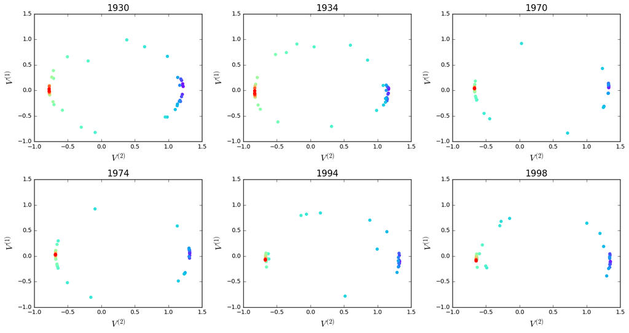

```python
yrs=[1930,1934,1970,1974,1994,1998]
PCA=[PCA_1930,PCA_1934,PCA_1970, PCA_1974, PCA_1994, PCA_1998]
fig, ax = plt.subplots(2, 3, figsize=(15,8 ))

#Start the index of the current subplot at 0
ax_ind = 0
ix=0
for j in range(0,2):
    ax_ind = j
    ix=ix
    #Iterate through all the shapes
    for i in range (0,3):
        pc12=PCA[ix]
        plot_pca_year_multi(pc12,str(yrs[ix]),ax_ind,i)
        ix+=1

plt.tight_layout()
plt.show()
```

**PC1PC2 visualization**

### PCA plots for biblical name distribution before and after history events

```python
PCA=[PCA_civil_before,PCA_civil_after,PCA_separate_before,PCA_separate_after]
col=["civil_before", "civil_after", "separate_before", "separate_after"]
```

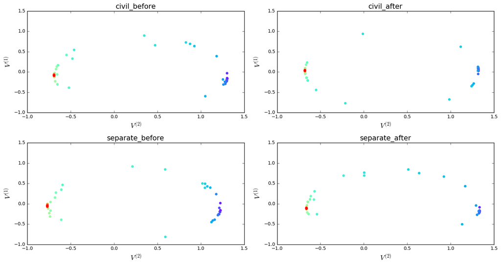

```python
fig, ax = plt.subplots(2, 2, figsize=(15,8 ))

#Start the index of the current subplot at 0
ax_ind = 0
ix=0
for j in range(0,2):
    ax_ind = j
    ix=ix
    #Iterate through all the shapes
    for i in range (0,2):
        pc12=PCA[ix]
        plot_pca_year_multi(pc12,col[ix],j,i)
        ix+=1

plt.tight_layout()
plt.show()
```

### PCA plots for whole name distribution before and after history events

```python
PCA=[PCA_WWII_before,PCA_WWII_after,PCA_depression_before, PCA_depression_after,PCA_feminism_fe_before,PCA_feminism_fe_after,PCA_feminism_ma_before,PCA_feminism_ma_after,PCA_alaska_before,PCA_alaska_after]
col=["WWII_before", "WWII_after", "depression_before", "depression_after","feminism_fe_before","feminism_fe_after","feminism_ma_before","feminism_ma_after","alaska_before","alaska_after"]
```

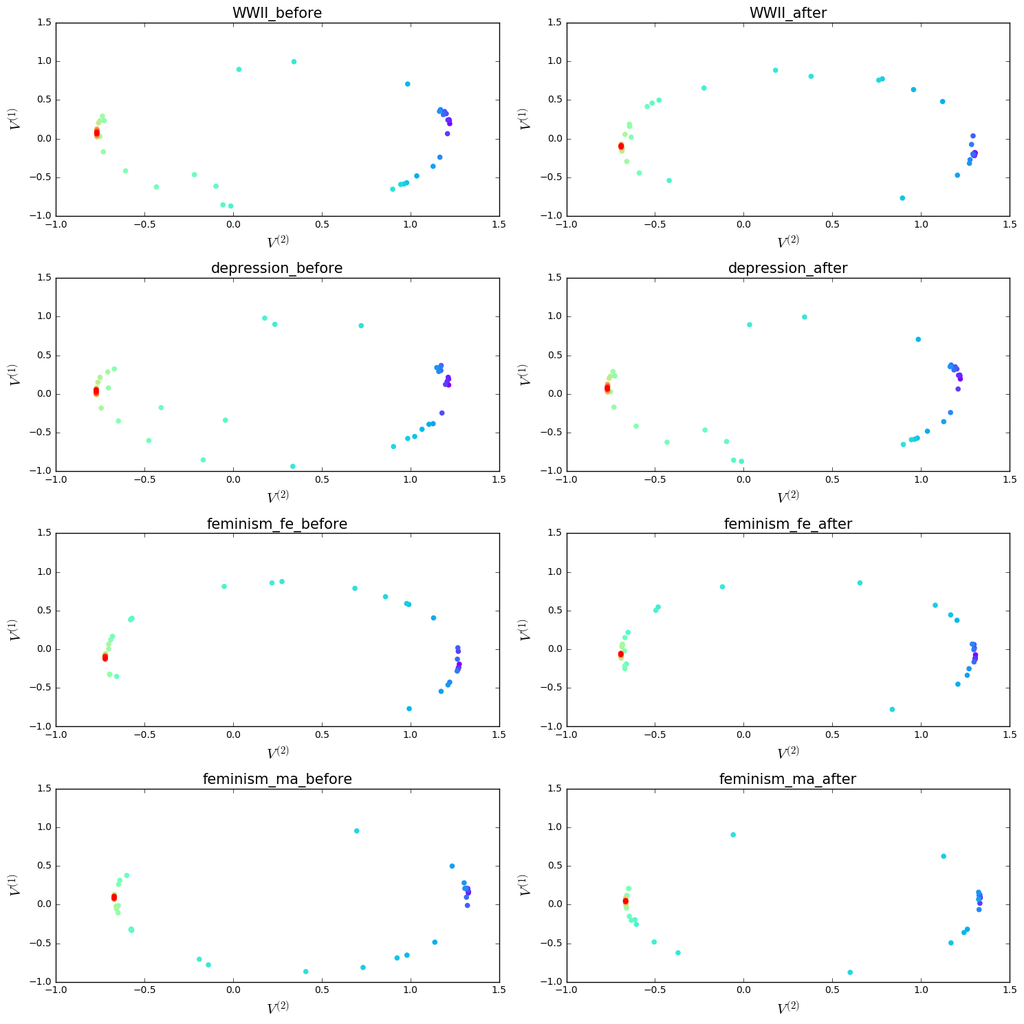

```python
fig, ax = plt.subplots(4, 2, figsize=(15,15 ))

#Start the index of the current subplot at 0
ax_ind = 0
ix=0
for j in range(0,4):
    ax_ind = j
    ix=ix
    #Iterate through all the shapes
    for i in range (0,2):
        pc12=PCA[ix]
        plot_pca_year_multi(pc12,col[ix],j,i)
        ix+=1

plt.tight_layout()
plt.show()
```

### Method section 8: Hierarchical Clustering

(Will cover more details in the Hierarchical Clustering & K-means Clustering section)

Hierarchical Clustering is a method to build a hierarchy of clusters starting from 51 clusters of one state each and such that clusters are merged as one moves up in the hierarchy.

**-Procedures:**

(1) choose number of cluster K, and the distance to compute

(2) Find the closest pair of states, put them into a single cluster

(3) merge clusters until you have K groups

**-Linkage Methods:**

Hierarchical Clustering also requires to choose linkage methods (How to group variables into a larger group and how to merge these groups until having K groups)

**Single Linkage**: similarity (binary distance calculated) between two clusters is the similarity between their two closest objects. Two groups are close if the smallest distance between two points in the opposite group is small. It measures the least dissimilar pair between groups.

**Complete Linkage**: similarity between two clusters is the proximity between their two most distant objects. It uses the furthest neighbor to determine the distance between two groups. Complete linkage is based on a pair of furtherest point, irrespective of all others. It measures the most dissimilar pair.

**Average Linkage**: similarity between two clusters is the arithmetic mean of all the similarity between the objects of one and the objects of the other. Average linkage averages pairwise dissimilarity, so clusters is not too compact or far apart too much.

**Mcquitty Linkage**: Similar to Average Linkages, but subclusters of which each of these two clusters were merged recently have equalized influence on that proximity. For example, if clusters 1 and 3 are to be joined into a new cluster, then the distance from 1 to cluster 4 is the average of the distances from 1 to 4 and 3 to 4. Here, distance depends on a combination of clusters instead of individual observations in the clusters.

**Wald Linkage**: With Ward's linkage method, the distance between two clusters is the sum of squared deviations from points (correaltion of states) to centroids. The goal of Ward's linkage method is to minimize the within-cluster sum of squares. It tends to produce clusters with similar numbers of observations.

**The number of K groups:** We plot the projections of the 51 states onto the plane made by the first two eigenvectors of cross-correlation matrix (from PCA). From the scatter plot (contains in the data visulization section) implies to how to choose number of K will be a reasonable number for clustering.

### Bibilical Name Cluster Over Time

```python
H=[]
states=list(df_WWII_before.index)
year=[1910,1914,1918,1922,1926,1930,1934,1938,1942,1946,1950,1954,1962,1966,1970,1974,1978,1982,1986,1990,1994,1998]
for y in year:
    H.append(converted_corr(corrstate(dfList[y])))

clustering = AgglomerativeClustering(linkage='ward', n_clusters=3)
clustering.fit(H[0])
Y=clustering.fit_predict(H[0])
for i in range(1,len(H)):
    clustering = AgglomerativeClustering(linkage='ward', n_clusters=3)
    clustering.fit(H[i])
    y=clustering.fit_predict(H[i])
    Y=np.vstack((Y,y))
Y=Y.T
df=pd.DataFrame(Y, columns=year, index=states)
df.head()
```

|  | 1910 | 1914 | 1918 | 1922 | 1926 | 1930 | 1934 | 1938 | 1942 | 1946 | ... | 1962 | 1966 | 1970 | 1974 | 1978 | 1982 | 1986 | 1990 | 1994 | 1998 |
| --- | --- | --- | --- | --- | --- | --- | --- | --- | --- | --- | --- | --- | --- | --- | --- | --- | --- | --- | --- | --- | --- |
| AK | 1 | 2 | 0 | 2 | 2 | 2 | 1 | 2 | 1 | 0 | ... | 1 | 0 | 0 | 2 | 1 | 0 | 1 | 1 | 1 | 2 |
| AL | 2 | 0 | 1 | 0 | 0 | 1 | 2 | 0 | 0 | 2 | ... | 2 | 0 | 0 | 1 | 1 | 0 | 1 | 1 | 1 | 1 |
| AR | 0 | 1 | 1 | 1 | 0 | 0 | 0 | 1 | 2 | 0 | ... | 1 | 0 | 0 | 2 | 1 | 0 | 1 | 1 | 1 | 2 |
| AZ | 1 | 2 | 0 | 2 | 2 | 2 | 1 | 2 | 1 | 0 | ... | 1 | 0 | 0 | 2 | 1 | 0 | 1 | 1 | 1 | 1 |
| CA | 0 | 1 | 1 | 0 | 0 | 1 | 2 | 0 | 0 | 1 | ... | 0 | 2 | 2 | 0 | 2 | 2 | 2 | 2 | 2 | 0 |

5 rows × 22 columns

### Biblical names clustering before and after Christian Related history events

```python
clustering = AgglomerativeClustering(linkage='ward', n_clusters=4)
clustering.fit(hier_civil_before)
y_hier_civil_before=clustering.labels_

clustering = AgglomerativeClustering(linkage='ward', n_clusters=4)
clustering.fit(hier_civil_after)
y_hier_civil_after=clustering.labels_

clustering = AgglomerativeClustering(linkage='ward', n_clusters=4)
clustering.fit(hier_separate_before)
y_hier_separate_before=clustering.labels_

clustering = AgglomerativeClustering(linkage='ward', n_clusters=4)
clustering.fit(hier_separate_after)
y_hier_separate_after=clustering.labels_

col=["civil_before", "civil_after", "separate_before", "separate_after"]
Y=[y_hier_civil_before,y_hier_civil_after, y_hier_separate_before, y_hier_separate_after]
Y=np.vstack((y_hier_civil_before,y_hier_civil_after, y_hier_separate_before, y_hier_separate_after)).T

states=list(df_civil_before.index)
df=pd.DataFrame(Y, columns=col, index=states)
df.head()
```

|  | civil_before | civil_after | separate_before | separate_after |
| --- | --- | --- | --- | --- |
| AK | 3 | 2 | 3 | 3 |
| AL | 2 | 0 | 0 | 2 |
| AR | 1 | 2 | 1 | 3 |
| AZ | 3 | 2 | 3 | 3 |
| CA | 0 | 3 | 2 | 0 |

### All names clustering before and after history events

```python
X=[hier_WWII_before, hier_WWII_after, hier_depression_before, hier_depression_after, hier_feminism_fe_before, hier_feminism_fe_after, hier_feminism_ma_before,hier_feminism_ma_after,hier_alaska_before,hier_alaska_after]
col=["WWII_before", "WWII_after", "depression_before", "depression_after","feminism_fe_before","feminism_fe_after","feminism_ma_before","feminism_ma_after","alaska_before","alaska_after"]
clustering = AgglomerativeClustering(linkage='ward', n_clusters=3)
clustering.fit(X[0])
y=clustering.labels_
Y=y
for i in range(1,len(X)):
    clustering = AgglomerativeClustering(linkage='ward', n_clusters=3)
    clustering.fit(X[i])
    y=clustering.labels_
    Y=np.vstack((Y,y))
Y=Y.T
df=pd.DataFrame(Y, columns=col, index=states)
df.head()
```

|  | WWII_before | WWII_after | depression_before | depression_after | feminism_fe_before | feminism_fe_after | feminism_ma_before | feminism_ma_after | alaska_before | alaska_after |
| --- | --- | --- | --- | --- | --- | --- | --- | --- | --- | --- |
| AK | 1 | 0 | 1 | 1 | 0 | 1 | 1 | 0 | 0 | 1 |
| AL | 0 | 2 | 0 | 0 | 2 | 2 | 0 | 0 | 2 | 2 |
| AR | 2 | 0 | 2 | 2 | 0 | 1 | 1 | 0 | 0 | 1 |
| AZ | 1 | 0 | 1 | 1 | 0 | 1 | 1 | 0 | 0 | 1 |
| CA | 0 | 1 | 0 | 0 | 1 | 0 | 2 | 2 | 1 | 0 |

### Method section 8: K-means Clustering

(Will cover more details in the Hierarchical Clustering & K-means Clustering section)

**K-means Clustering: partition the points into K groups (need to specify K) such that the sum of squares from points to the assigned cluster centers (Euclidean distance) is minimized.**

**-Procedures:**

(1) initialize K cluster centroids randomly

(2) compute the distance to each cluster, then assign each to a group by minimize the total of distance

(3) update centroid = mean of points in the group; Then keep doing (2) and (3) until centers no longer change

**-Results:** K groups of states

In our analysis, we choose the same number of K as we chose for Hierarchical Clustering.

### Bibilical Name Cluster Over Time

```python
kmeans = KMeans(n_clusters=3)
kmeans.fit(H[0])
Y=kmeans.labels_
for i in range(1,len(H)):
    kmeans = KMeans(n_clusters=3)
    kmeans.fit(H[i])
    y=kmeans.labels_
    Y=np.vstack((Y,y))
Y=Y.T
df2=pd.DataFrame(Y, columns=year, index=states)
df2.head()
```

|  | 1910 | 1914 | 1918 | 1922 | 1926 | 1930 | 1934 | 1938 | 1942 | 1946 | ... | 1962 | 1966 | 1970 | 1974 | 1978 | 1982 | 1986 | 1990 | 1994 | 1998 |
| --- | --- | --- | --- | --- | --- | --- | --- | --- | --- | --- | --- | --- | --- | --- | --- | --- | --- | --- | --- | --- | --- |
| AK | 0 | 2 | 1 | 1 | 0 | 0 | 1 | 1 | 1 | 1 | ... | 0 | 1 | 0 | 0 | 0 | 0 | 0 | 1 | 0 | 0 |
| AL | 2 | 1 | 0 | 0 | 1 | 1 | 2 | 0 | 0 | 2 | ... | 2 | 1 | 2 | 2 | 0 | 0 | 0 | 1 | 0 | 0 |
| AR | 1 | 0 | 1 | 2 | 2 | 2 | 0 | 2 | 1 | 1 | ... | 0 | 1 | 0 | 0 | 0 | 0 | 0 | 1 | 0 | 0 |
| AZ | 0 | 2 | 1 | 1 | 0 | 0 | 1 | 1 | 1 | 1 | ... | 0 | 1 | 0 | 0 | 0 | 0 | 0 | 1 | 0 | 2 |
| CA | 1 | 0 | 1 | 0 | 1 | 1 | 2 | 0 | 2 | 0 | ... | 1 | 0 | 1 | 1 | 1 | 1 | 1 | 0 | 1 | 1 |

5 rows × 22 columns

### Biblical names clustering before and after Christian Related history events

```python
col=["civil_before", "civil_after", "separate_before", "separate_after"]
kmeans = KMeans(n_clusters=4)
kmeans.fit(hier_civil_before)
Y1=kmeans.labels_

kmeans = KMeans(n_clusters=4)
kmeans.fit(hier_civil_after)
Y2=kmeans.labels_

kmeans = KMeans(n_clusters=4)
kmeans.fit(hier_separate_before)
Y3=kmeans.labels_

kmeans = KMeans(n_clusters=4)
kmeans.fit(hier_separate_after)
Y4=kmeans.labels_

Y=np.vstack((Y1,Y2,Y3,Y4)).T
df=pd.DataFrame(Y, columns=col, index=states)
df.head()
```

|  | civil_before | civil_after | separate_before | separate_after |
| --- | --- | --- | --- | --- |
| AK | 0 | 0 | 0 | 3 |
| AL | 2 | 3 | 2 | 2 |
| AR | 0 | 0 | 3 | 3 |
| AZ | 0 | 0 | 0 | 3 |
| CA | 1 | 1 | 1 | 1 |

### All names clustering before and after history events

```python
col=["WWII_before", "WWII_after", "depression_before", "depression_after","feminism_fe_before","feminism_fe_after","feminism_ma_before","feminism_ma_after","alaska_before","alaska_after"]
clustering = KMeans(n_clusters=3)
clustering.fit(X[0])
y=clustering.labels_
Y=y
for i in range(1,len(X)):
    clustering = KMeans(n_clusters=3)
    clustering.fit(X[i])
    y=clustering.labels_
    Y=np.vstack((Y,y))
Y=Y.T
df1=pd.DataFrame(Y, columns=col, index=states)
df1.head()
```

|  | WWII_before | WWII_after | depression_before | depression_after | feminism_fe_before | feminism_fe_after | feminism_ma_before | feminism_ma_after | alaska_before | alaska_after |
| --- | --- | --- | --- | --- | --- | --- | --- | --- | --- | --- |
| AK | 0 | 0 | 1 | 1 | 0 | 0 | 0 | 0 | 0 | 0 |
| AL | 1 | 2 | 0 | 2 | 2 | 2 | 2 | 2 | 2 | 2 |
| AR | 2 | 0 | 2 | 0 | 0 | 0 | 0 | 0 | 0 | 0 |
| AZ | 0 | 0 | 1 | 1 | 0 | 0 | 0 | 0 | 0 | 0 |
| CA | 1 | 1 | 0 | 2 | 1 | 1 | 1 | 1 | 1 | 1 |